# Credit Risk Prediction Project Report

Lucas Varela

2024-01-22

## Introduction

This machine learning project aims to predict credit risk using a dataset containing various attributes related to individuals’ credit applications. The dataset includes information such as checking account status, credit history, purpose of credit, credit amount, employment details, and more.

## Data Preprocessing

No missing values were found in the dataset, ensuring a complete and reliable data:

```r
sum(colSums(is.na(credit_data)))
```

```
## [1] 0
```

Categorical variables were converted to factors for compatibility with machine learning algorithms:

```r
credit_data <- credit_data %>%
    mutate_if(is.character, as.factor)
```

## Exploratory Data Analysis (EDA)

```r
summary(credit_data)
```

```
##     checking_status    duration                           credit_history
##  <0         :274    Min.   : 4.0   all paid                      : 49
##  >=200      : 63    1st Qu.:12.0   critical/other existing credit:293
##  0<=X<200   :269    Median :18.0   delayed previously            : 88
##  no checking:394    Mean   :20.9   existing paid                 :530
##                     3rd Qu.:24.0   no credits/all paid           : 40
##                     Max.   :72.0
##
##                 purpose    credit_amount            savings_status      employment
##  radio/tv           :280   Min.   :  250   <100            :603    <1        :172
##  new car            :234   1st Qu.: 1366   >=1000          : 48    >=7       :253
##  furniture/equipment:181   Median : 2320   100<=X<500      :103    1<=X<4    :339
##  used car           :103   Mean   : 3271   500<=X<1000     : 63    4<=X<7    :174
##  business           : 97   3rd Qu.: 3972   no known savings:183    unemployed: 62
##  education          : 50   Max.   :18424
##  (Other)            : 55
##  installment_commitment           personal_status      other_parties residence_since
##  Min.   :1.000          female div/dep/mar:310    co applicant: 41   Min.   :1.000
##  1st Qu.:2.000          male div/sep      : 50    guarantor   : 52   1st Qu.:2.000
##  Median :3.000          male mar/wid      : 92    none        :907   Median :3.000
##  Mean   :2.973          male single       :548                       Mean   :2.845
##  3rd Qu.:4.000                                                       3rd Qu.:4.000
##  Max.   :4.000                                                       Max.   :4.000
##
##          property_magnitude      age        other_payment_plans     housing
##  car              :332      Min.   :19.00   bank  :139          for free:108
##  life insurance   :232      1st Qu.:27.00   none  :814          own     :713
##  no known property:154      Median :33.00   stores: 47          rent    :179
##  real estate      :282      Mean   :35.55
##                             3rd Qu.:42.00
##                             Max.   :75.00
##
##  existing_credits                        job      num_dependents  own_telephone foreign_worker
##  Min.   :1.000    high qualif/self emp/mgmt:148   Min.   :1.000   none:596      no : 37
##  1st Qu.:1.000    skilled                  :630   1st Qu.:1.000   yes :404      yes:963
##  Median :1.000    unemp/unskilled non res  : 22   Median :1.000
##  Mean   :1.407    unskilled resident       :200   Mean   :1.155
##  3rd Qu.:2.000                                    3rd Qu.:1.000
##  Max.   :4.000                                    Max.   :2.000
##
##   class
##  bad :300
##  good:700
##
##
##
##
##
```

## Model Training and Evaluation

The dataset was divided into training (80%) and testing (20%) sets using a random seed for reproducibility

```r
set.seed(123)
train_index <- createDataPartition(credit_data$class, p = 0.8, list = FALSE)
train_data <- credit_data[train_index, ]
test_data <- credit_data[-train_index, ]
```

A random forest classifier with 100 trees was chosen for its ability to handle complex relationships in the data.

```r
model <- randomForest(class ~ ., data = train_data, ntree = 100)
```

Finally we need to evaluate the model, the confusion matrix and related statistics for the test set are as follows:

```r
predictions <- predict(model, test_data)
conf_matrix <- confusionMatrix(predictions, test_data$class)
print(conf_matrix)
```

```
## Confusion Matrix and Statistics
##
##           Reference
## Prediction bad good
##       bad   22   14
##       good  38  126
##
##                Accuracy : 0.74
##                  95% CI : (0.6734, 0.7993)
##     No Information Rate : 0.7
##     P-Value [Acc > NIR] : 0.122775
##
##                   Kappa : 0.3011
##
##  Mcnemar's Test P-Value : 0.001425
##
##             Sensitivity : 0.3667
##             Specificity : 0.9000
##          Pos Pred Value : 0.6111
##          Neg Pred Value : 0.7683
##              Prevalence : 0.3000
##          Detection Rate : 0.1100
##    Detection Prevalence : 0.1800
##       Balanced Accuracy : 0.6333
##
##        'Positive' Class : bad
##
```

This confusion matrix indicates the performance of our machine learning model on a binary classification task. Here’s a brief analysis:

- **Accuracy:** The model’s overall accuracy is 74%, meaning it correctly predicted the class for 74% of the instances.
- **Sensitivity (True Positive Rate):** The ability to correctly identify the ‘bad’ class is 36.67%. This suggests the model struggles with capturing instances of the ‘bad’ class.
- **Specificity (True Negative Rate):** The model performs well in correctly identifying the ‘good’ class, with a specificity of 90%.
- **Precision (Pos Pred Value):** Of the instances predicted as ‘bad’ by the model, 61.11% are actually ‘bad’. This metric reflects the precision of the positive predictions.
- **Kappa:** Kappa coefficient measures the agreement between the model’s predictions and actual values, adjusted for chance. A value of 0.3011 suggests a fair agreement.
- **Mcnemar’s Test P-Value:** The p-value of 0.001425 from McNemar’s test indicates a significant difference between the model’s predictions and the actual outcomes.

## Feature Importance

The random forest model assigned importance scores to each feature.

```r
importance(model)
```

```
##                        MeanDecreaseGini
## checking_status               40.407370
## duration                      29.064416
## credit_history                22.344640
## purpose                       30.720590
## credit_amount                 40.236548
## savings_status                19.114812
## employment                    17.897506
## installment_commitment        12.708324
## personal_status               12.388412
## other_parties                  6.529381
## residence_since               11.831950
## property_magnitude            15.393694
## age                           32.370946
## other_payment_plans            7.748471
## housing                        7.359178
## existing_credits               7.069289
## job                            9.300422
## num_dependents                 4.004887
## own_telephone                  4.825012
## foreign_worker                 1.478207
```

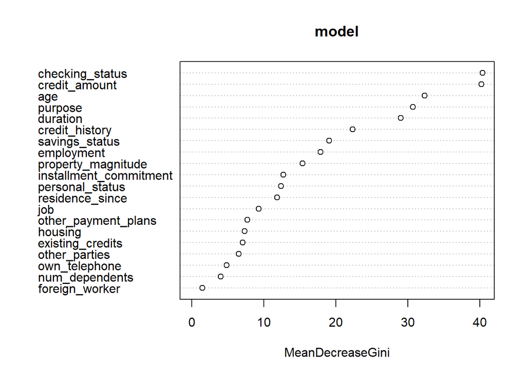

```r
varImpPlot(model)
```